# Predicción

2025-05-22

```r
library(dplyr) #Manipulación de datos (filtrar, agrupar, mutar, resumir)
library(readr) #Lectura de archivos CSV/TXT de forma rápida
library(randomForest) #Algoritmo de aprendizaje basado en árboles (ensemble)
library(Metrics) #Calcular métricas de evaluación: rmse(), mae()...
```

```r
library(ggplot2) #Crear gráficos (puntos, líneas, histogramas, facetas...)
library(tidyr) #Reformatear datos (pivot_longer, pivot_wider, drop_na)
library(tibble) #Alternativa moderna a data.frame, más limpia
library(stringr) #Manipulación de texto (str_extract, str_remove, etc.)
library(broom) #Extraer resultados limpios de modelos (tidy(), glance())
library(knitr) #Generar documentos (Rmd → HTML, Word, PDF) y tablas con kable()
library(kableExtra) #Decorar tablas HTML/Word (kable_styling, colores, alineación)
library(xgboost) #Modelo de predicción avanzado basado en boosting
library(purrr) #Aplicar funciones a listas (map(), map_df()) → ideal para loops funcionales
```

```r
barrios_reseñas <- read_csv('barriosResenas.csv', show_col_types = FALSE) %>%
  rename(barrio = neighbourhood_cleansed) %>%
  rename(puntuacion_media_normal_reseñas = puntuacion_media_normal) %>%
  rename(puntuacion_media_reseñas = puntuacion_media)

# Cargar datos fiabilidad y pisos
pisos_fiabilidad <- read_csv('pisos_con_analisis_fiabilidad.csv', show_col_types = FALSE) %>%
  rename(barrio = neighbourhood_cleansed) %>%
  rename(precio_ponderado_vivienda = precio_ponderado)
pisos_limpios <- read_csv('pisos_limpios.csv', show_col_types = FALSE) %>%
  rename(barrio = neighbourhood_cleansed)
# Cargar archivo barrios con precios medios
barrios <- read_csv("barrios_cluster_variables.csv", show_col_types = FALSE) %>%
  rename(barrio = neighbourhood_cleansed) %>%
  select(barrio, precio_ponderado_vivienda_media, precio_ponderado_barrio_media)

  #Cargar datos reseñas
reseñas <- read_csv("clustersResenas.csv", show_col_types = FALSE) %>%
  rename(cluster_text = 1) %>%
  rename(puntuacion_media_reseñas_ = puntuacion_media) %>%
  rename(reseñas_media_normalizada_cluster = puntuacion_media_normal) %>%
  mutate(cluster = str_extract(cluster_text, "\\d+")) %>%   # Extrae "1", "2", etc.
  select(-cluster_text)
# Cargar y añadir cluster a cada uno
cluster1 <- read_csv("cluster1.csv", show_col_types = FALSE) %>% mutate(cluster = 1)
cluster2 <- read_csv("cluster2.csv", show_col_types = FALSE) %>% mutate(cluster = 2)
cluster3 <- read_csv("cluster3.csv", show_col_types = FALSE) %>% mutate(cluster = 3)
cluster4 <- read_csv("cluster4.csv", show_col_types = FALSE) %>% mutate(cluster = 4)
# Unir todos los clusters
clusters <- bind_rows(cluster1, cluster2, cluster3, cluster4)

# Unir clusters con pisos
pisos_cluster <- pisos_limpios %>%
  left_join(clusters %>% select(barrio, cluster), by = "barrio") %>%
  mutate(cluster = as.character(cluster))

# Unir reseñas con pisos
pisos_reseñas <- pisos_cluster %>%
  left_join(reseñas, by = "cluster")

# Unir al dataset de viviendas
pisos_final <- pisos_reseñas %>%
  left_join(barrios, by = "barrio")

pisos_final <- pisos_final %>% select(-1)

pisos_final <- pisos_final %>%
  left_join(pisos_fiabilidad %>%
      select(id, score_fiabilidad, fiabilidad_normalizada, score_fiabilidad_0a5, precio_ponderado_barrio, precio_ponderado_vivienda),
    by = c("listing_id" = "id")
  )

# Unir al dataset de viviendas
pisos_final <- pisos_final %>%
  left_join(barrios_reseñas, by = "barrio")

pisos_final <- pisos_final %>% select(-1)
```

```r
# Filtrar columnas clave y eliminar filas incompletas
datos_modelo <- pisos_final %>%
  select(price, # Variable objetivo (precio real)
    bedrooms, bathrooms, accommodates,     # Variables físicas
    precio_ponderado_barrio_media, barrio,
    precio_ponderado_vivienda_media, precio_ponderado_barrio, precio_ponderado_vivienda,
    fiabilidad_normalizada, reseñas_media_normalizada_cluster, puntuacion_media_normal_reseñas,
    cluster
  ) %>%
  filter(complete.cases(.)) %>%  # Elimina filas con valores faltantes
  mutate(cluster = as.factor(cluster))  # Convierte a factor para modelos

# Eliminar outliers extremos (5% inferior y 5% superior del precio)
cuantiles <- quantile(datos_modelo$price, probs = c(0.05, 0.95), na.rm = TRUE)

datos_modelo <- datos_modelo %>%
  filter(price >= cuantiles[1], price <= cuantiles[2])
```

```r
# Añadir log_precio
datos_modelo <- datos_modelo %>%
  mutate(log_precio = log(price + 1))

# Dividir en train/test (80/20)
set.seed(123)
n <- nrow(datos_modelo)
train_indices <- sample(1:n, size = 0.8 * n)

train <- datos_modelo[train_indices, ]
test <- datos_modelo[-train_indices, ]
```

Se transformó en log para suavizar el impacto de los valores extremos, mejorar la relación lineal entre variables predictoras y el objetivo y facilitar una predicción más precisa en el rango central de precios.

```r
# Eliminar columnas no numéricas y preparar matrices
x_vars <- c(
  "bedrooms", "bathrooms", "accommodates", "precio_ponderado_barrio_media",
  "fiabilidad_normalizada",
  "puntuacion_media_normal_reseñas")

# PERO mantener cluster y barrio en el dataframe
train$cluster <- datos_modelo[train_indices, "cluster"]
test$cluster <- datos_modelo$cluster[-train_indices]
train$barrio <- datos_modelo[train_indices, "barrio"]
test$barrio <- datos_modelo[-train_indices, "barrio"]

X_train <- as.matrix(sapply(train[, x_vars], as.numeric))
X_test <- as.matrix(sapply(test[, x_vars], as.numeric))
y_train <- train$log_precio
y_test <- test$log_precio
```

```r
# Modelo de regresión lineal
modelo_lm <- lm(log_precio ~ bedrooms + bathrooms + accommodates +
                  precio_ponderado_vivienda_media + precio_ponderado_barrio_media +
                  fiabilidad_normalizada +
                  puntuacion_media_normal_reseñas +
                  reseñas_media_normalizada_cluster,
                data = train)

# Predicciones
pred_log_lm <- predict(modelo_lm, newdata = test)
pred_lm <- exp(pred_log_lm) - 1
real <- exp(test$log_precio) - 1

# Evaluación
data.frame(
  Modelo = "Regresión Lineal",
  RMSE = rmse(real, pred_lm),
  MAE = mae(real, pred_lm),
  R2 = cor(real, pred_lm)^2
)
```

| Modelo | RMSE | MAE | R2 |
| --- | --- | --- | --- |
| Regresión Lineal | 32.04584 | 23.51033 | 0.2207937 |

```r
# Entrenar random forest
modelo_rf <- randomForest(
  formula = log_precio ~ bedrooms + bathrooms + accommodates +
    precio_ponderado_vivienda_media + precio_ponderado_barrio_media +
    fiabilidad_normalizada +
    puntuacion_media_normal_reseñas,
  data = train,
  ntree = 500,
  importance = TRUE
)

# Predicciones
pred_log_rf <- predict(modelo_rf, newdata = test)
pred_rf <- exp(pred_log_rf) - 1

# Evaluación
data.frame(
  Modelo = "Random Forest",
  RMSE = rmse(real, pred_rf),
  MAE = mae(real, pred_rf),
  R2 = cor(real, pred_rf)^2
)
```

| Modelo | RMSE | MAE | R2 |
| --- | --- | --- | --- |
| Random Forest | 31.52367 | 22.84907 | 0.2393391 |

```r
modelo_xgb <- xgboost(
  data = X_train,
  label = y_train,
  nrounds = 100,
  max_depth = 4,
  eta = 0.1,
  objective = "reg:squarederror",
  verbose = 0
)

# Predicción
pred_log <- predict(modelo_xgb, X_test)
pred <- exp(pred_log) - 1
real <- exp(y_test) - 1

# Métricas
data.frame(
  RMSE = rmse(real, pred),
  MAE = mae(real, pred),
  R2 = cor(real, pred)^2
)
```

| RMSE | MAE | R2 |
| --- | --- | --- |
| 31.10384 | 22.85432 | 0.2703167 |

```r
# Reutilizamos train y test definidos antes
real <- exp(test$log_precio) - 1

# Modelo lineal
modelo_lm <- lm(log_precio ~ ., data = train[, c(x_vars, "log_precio")])
pred_lm <- exp(predict(modelo_lm, newdata = test)) - 1

# Modelo Random Forest
modelo_rf <- randomForest(
  formula = log_precio ~ .,
  data = train[, c(x_vars, "log_precio")],
  ntree = 500,
  importance = TRUE
)
pred_rf <- exp(predict(modelo_rf, newdata = test)) - 1

# Ya tienes modelo_xgb y pred_xgb = pred

# Guardar resultados
comparacion_modelos <- bind_rows(
  tibble(Modelo = "XGBoost", RMSE = rmse(real, pred), MAE = mae(real, pred), R2 = cor(real, pred)^2),
  tibble(Modelo = "Random Forest", RMSE = rmse(real, pred_rf), MAE = mae(real, pred_rf), R2 = cor(real, pred_rf)^2),
  tibble(Modelo = "Regresión Lineal", RMSE = rmse(real, pred_lm), MAE = mae(real, pred_lm), R2 = cor(real, pred_lm)^2)
)
```

```r
comparacion_modelos %>%
  kable(digits = 2) %>%
  kable_styling(full_width = FALSE)
```

| Modelo | RMSE | MAE | R2 |
| --- | --- | --- | --- |
| XGBoost | 31.10 | 22.85 | 0.27 |
| Random Forest | 31.45 | 22.82 | 0.24 |
| Regresión Lineal | 32.51 | 24.19 | 0.20 |

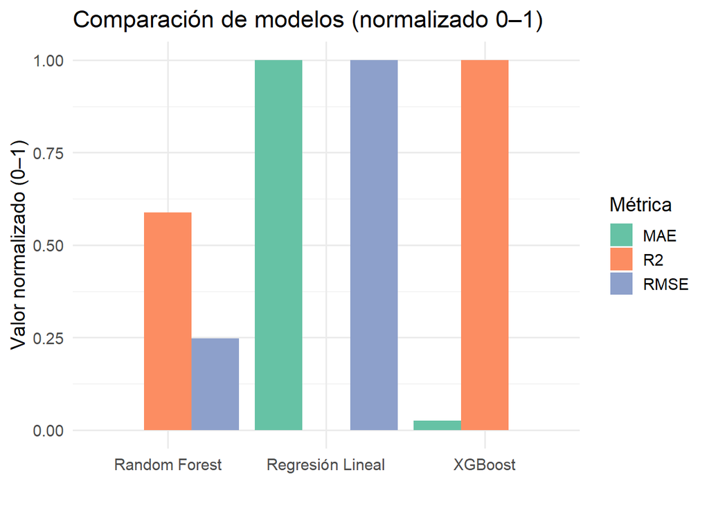

```r
# Normalizar cada métrica a escala 0–1 para comparación visual
comparacion_norm <- comparacion_modelos %>%
  mutate(
    RMSE_norm = (RMSE - min(RMSE)) / (max(RMSE) - min(RMSE)),
    MAE_norm = (MAE - min(MAE)) / (max(MAE) - min(MAE)),
    R2_norm = (R2 - min(R2)) / (max(R2) - min(R2))
  ) %>%
  select(Modelo, RMSE = RMSE_norm, MAE = MAE_norm, R2 = R2_norm) %>%
  pivot_longer(cols = c(RMSE, MAE, R2), names_to = "Métrica", values_to = "Valor")

# Gráfico comparativo proporcional
ggplot(comparacion_norm, aes(x = Modelo, y = Valor, fill = Métrica)) +
  geom_col(position = "dodge") +
  labs(
    title = "Comparación de modelos (normalizado 0–1)",
    y = "Valor normalizado (0–1)",
    x = ""
  ) +
  theme_minimal(base_size = 14) +
  scale_fill_brewer(palette = "Set2")
```

XGBoost se comporta como el modelo más completo: explica mejor la variabilidad del precio y mantiene un error razonablemente bajo. Random Forest ofrece predicciones algo más conservadoras y precisas en euros, pero con menos poder explicativo. La regresión lineal no capta bien las complejidades del precio de vivienda

```r
  # Calcular importancia
  importance_matrix <- xgb.importance(model = modelo_xgb)

  # Mostrar como tabla
  importance_matrix %>%
    kable() %>%
    kable_styling(full_width = FALSE, bootstrap_options = c("striped", "hover"))
```

| Feature | Gain | Cover | Frequency |
| --- | --- | --- | --- |
| fiabilidad_normalizada | 0.3483791 | 0.3982179 | 0.4302120 |
| bedrooms | 0.1693380 | 0.0577319 | 0.0918728 |
| bathrooms | 0.1579040 | 0.0562483 | 0.0812721 |
| accommodates | 0.1250424 | 0.1316585 | 0.1042403 |
| precio_ponderado_barrio_media | 0.1129366 | 0.1723703 | 0.1704947 |
| puntuacion_media_normal_reseñas | 0.0864000 | 0.1837731 | 0.1219081 |

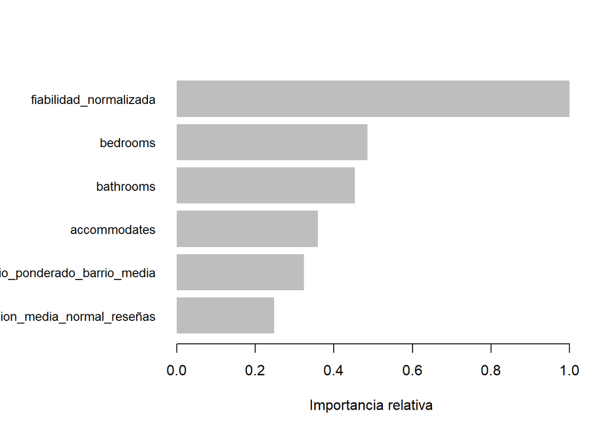

```r
  # Gráfico de importancia
  xgb.plot.importance(importance_matrix, top_n = 10, rel_to_first = TRUE,
                      xlab = "Importancia relativa")
```

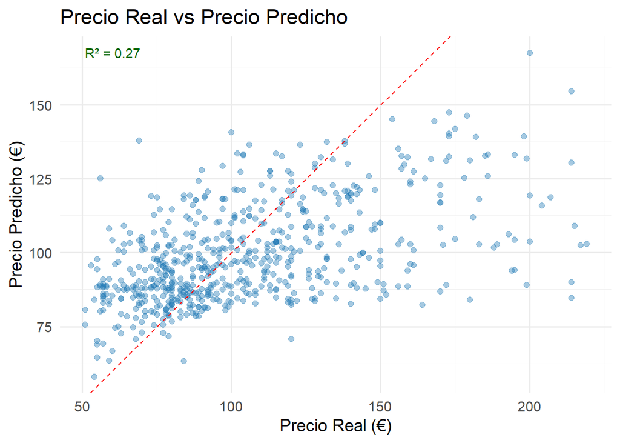

```r
# Crear dataframe con resultados
resultados <- test %>%
  mutate(
    precio_real = exp(log_precio) - 1,
    precio_predicho = pred
  )

# Gráfico
ggplot(resultados, aes(x = precio_real, y = precio_predicho)) +
  geom_point(alpha = 0.4, color = "#1f78b4", size = 2) +
  geom_abline(slope = 1, intercept = 0, color = "red", linetype = "dashed") +
  labs(
    title = "Precio Real vs Precio Predicho",
    x = "Precio Real (€)",
    y = "Precio Predicho (€)"
  ) +
  theme_minimal(base_size = 14) +
  annotate("text", x = min(resultados$precio_real), y = max(resultados$precio_predicho),
           label = paste("R² =", round(cor(resultados$precio_real, resultados$precio_predicho)^2, 3)),
           hjust = 0, color = "darkgreen")
```

```r
resultados_clusters <- datos_modelo %>%
  split(.$cluster) %>%
  map_df(function(df) {
    if (nrow(df) < 20) return(NULL)  # evitar errores con clusters pequeños

    set.seed(123)
    train_indices <- sample(1:nrow(df), size = 0.8 * nrow(df))
    train <- df[train_indices, ]
    test <- df[-train_indices, ]

    x_vars <- c("bedrooms", "bathrooms", "accommodates",
                "precio_ponderado_barrio_media",
                "fiabilidad_normalizada",
                "puntuacion_media_normal_reseñas")

    X_train <- as.matrix(sapply(train[, x_vars], as.numeric))
    X_test <- as.matrix(sapply(test[, x_vars], as.numeric))
    y_train <- log(train$price + 1)
    y_test <- log(test$price + 1)

    modelo <- xgboost(data = X_train, label = y_train, nrounds = 100,
                      max_depth = 4, eta = 0.1, objective = "reg:squarederror", verbose = 0)

    pred <- exp(predict(modelo, X_test)) - 1
    real <- exp(y_test) - 1

    resultado <- tibble(
      cluster = unique(df$cluster),
      RMSE = rmse(real, pred),
      MAE = mae(real, pred),
      R2 = cor(real, pred)^2
    )

    print(resultado)  # Mostrar resultado por consola
    return(resultado)
  })
```

```
## # A tibble: 1 × 4
##   cluster  RMSE   MAE    R2
##   <fct>   <dbl> <dbl> <dbl>
## 1 1        31.5  24.6 0.285
## # A tibble: 1 × 4
##   cluster  RMSE   MAE    R2
##   <fct>   <dbl> <dbl> <dbl>
## 1 2        33.1  23.7 0.173
## # A tibble: 1 × 4
##   cluster  RMSE   MAE    R2
##   <fct>   <dbl> <dbl> <dbl>
## 1 3        36.6  27.4 0.190
## # A tibble: 1 × 4
##   cluster  RMSE   MAE    R2
##   <fct>   <dbl> <dbl> <dbl>
## 1 4        29.9  22.8 0.248
```

```r
# Tabla final
resultados_clusters %>%
  rename("Cluster" = cluster, "Error Medio (RMSE)" = RMSE,
         "Error Absoluto (MAE)" = MAE, "Variabilidad Explicada (R²)" = R2) %>%
  kable() %>%
  kable_styling(full_width = FALSE)
```

| Cluster | Error Medio (RMSE) | Error Absoluto (MAE) | Variabilidad Explicada (R²) |
| --- | --- | --- | --- |
| 1 | 31.48091 | 24.61647 | 0.2850278 |
| 2 | 33.13467 | 23.68081 | 0.1734142 |
| 3 | 36.64418 | 27.36977 | 0.1900675 |
| 4 | 29.89712 | 22.78005 | 0.2483261 |

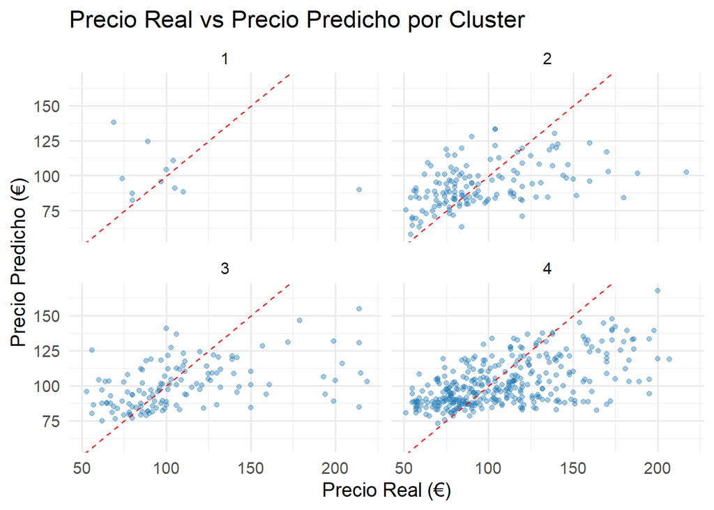

```r
# Suponiendo que test ya tiene: precio_real, precio_predicho y cluster
resultados_cluster <- test %>%
  mutate(
    precio_real = exp(log_precio) - 1,
    precio_predicho = pred
  )

# Gráfico con facetas por cluster
ggplot(resultados_cluster, aes(x = precio_real, y = precio_predicho)) +
  geom_point(alpha = 0.4, color = "#1f78b4", size = 1.5) +
  geom_abline(slope = 1, intercept = 0, linetype = "dashed", color = "red") +
  facet_wrap(~cluster) +
  labs(
    title = "Precio Real vs Precio Predicho por Cluster",
    x = "Precio Real (€)",
    y = "Precio Predicho (€)"
  ) +
  theme_minimal(base_size = 14)
```

```r
resultados_barrios <- datos_modelo %>%
  split(.$barrio) %>%
  map_df(function(df) {
    if (nrow(df) < 20) return(NULL)  # evitar barrios con pocos datos

    set.seed(123)
    train_indices <- sample(1:nrow(df), size = 0.8 * nrow(df))
    train <- df[train_indices, ]
    test <- df[-train_indices, ]

    x_vars <- c("bedrooms", "bathrooms", "accommodates",
                "precio_ponderado_barrio_media",
                "fiabilidad_normalizada",
                "puntuacion_media_normal_reseñas")

    X_train <- as.matrix(sapply(train[, x_vars], as.numeric))
    X_test <- as.matrix(sapply(test[, x_vars], as.numeric))
    y_train <- log(train$price + 1)
    y_test <- log(test$price + 1)

    modelo <- xgboost(
      data = X_train,
      label = y_train,
      nrounds = 100,
      max_depth = 4,
      eta = 0.1,
      objective = "reg:squarederror",
      verbose = 0
    )

    pred <- exp(predict(modelo, X_test)) - 1
    real <- exp(y_test) - 1

    resultado <- tibble(
      barrio = unique(df$barrio),
      RMSE = rmse(real, pred),
      MAE = mae(real, pred),
      R2 = cor(real, pred)^2
    )

    print(resultado)  # Mostrar resultado por consola
    return(resultado)
  })
```

```
## # A tibble: 1 × 4
##   barrio  RMSE   MAE    R2
##   <chr>  <dbl> <dbl> <dbl>
## 1 AIORA   30.4  18.6 0.393
## # A tibble: 1 × 4
##   barrio  RMSE   MAE    R2
##   <chr>  <dbl> <dbl> <dbl>
## 1 ALBORS  36.5  25.2 0.119
## # A tibble: 1 × 4
##   barrio       RMSE   MAE    R2
##   <chr>       <dbl> <dbl> <dbl>
## 1 ARRANCAPINS  36.3  26.9 0.168
## # A tibble: 1 × 4
##   barrio     RMSE   MAE    R2
##   <chr>     <dbl> <dbl> <dbl>
## 1 BENICALAP  53.9  30.8 0.186
## # A tibble: 1 × 4
##   barrio      RMSE   MAE    R2
##   <chr>      <dbl> <dbl> <dbl>
## 1 BENIMACLET  31.6  28.7 0.240
## # A tibble: 1 × 4
##   barrio               RMSE   MAE    R2
##   <chr>               <dbl> <dbl> <dbl>
## 1 CABANYAL-CANYAMELAR  25.6  19.4 0.382
## # A tibble: 1 × 4
##   barrio                                RMSE   MAE    R2
##   <chr>                                <dbl> <dbl> <dbl>
## 1 CIUTAT DE LES ARTS I DE LES CIENCIES  17.3  13.1 0.725
## # A tibble: 1 × 4
##   barrio        RMSE   MAE     R2
##   <chr>        <dbl> <dbl>  <dbl>
## 1 CIUTAT JARDI  19.1  8.52 0.0262
## # A tibble: 1 × 4
##   barrio      RMSE   MAE    R2
##   <chr>      <dbl> <dbl> <dbl>
## 1 EL BOTANIC  29.3  20.6 0.214
## # A tibble: 1 × 4
##   barrio    RMSE   MAE    R2
##   <chr>    <dbl> <dbl> <dbl>
## 1 EL CARME  24.6  15.7 0.481
```

[output cut: 77 more lines]

```
##   barrio      RMSE   MAE     R2
##   <chr>      <dbl> <dbl>  <dbl>
## 1 PENYA-ROJA  46.0  34.2 0.0114
## # A tibble: 1 × 4
##   barrio   RMSE   MAE    R2
##   <chr>   <dbl> <dbl> <dbl>
## 1 RUSSAFA  27.3  18.6 0.368
## # A tibble: 1 × 4
##   barrio         RMSE   MAE    R2
##   <chr>         <dbl> <dbl> <dbl>
## 1 SANT FRANCESC  29.2  25.2 0.505
## # A tibble: 1 × 4
##   barrio    RMSE   MAE      R2
##   <chr>    <dbl> <dbl>   <dbl>
## 1 TRINITAT  60.8  40.5 0.00434
```

```r
# Tabla final
resultados_barrios %>%
  rename("Barrios" = barrio, "Error Medio (RMSE)" = RMSE,
         "Error Absoluto (MAE)" = MAE, "Variabilidad Explicada (R²)" = R2) %>%
  kable() %>%
  kable_styling(full_width = FALSE)
```

| Barrios | Error Medio (RMSE) | Error Absoluto (MAE) | Variabilidad Explicada (R²) |
| --- | --- | --- | --- |
| AIORA | 30.44133 | 18.644351 | 0.3931851 |
| ALBORS | 36.51812 | 25.194352 | 0.1187561 |
| ARRANCAPINS | 36.31233 | 26.900144 | 0.1679798 |
| BENICALAP | 53.94661 | 30.772631 | 0.1855498 |
| BENIMACLET | 31.61886 | 28.690716 | 0.2395053 |
| CABANYAL-CANYAMELAR | 25.57267 | 19.360126 | 0.3816936 |
| CIUTAT DE LES ARTS I DE LES CIENCIES | 17.29255 | 13.097678 | 0.7245705 |
| CIUTAT JARDI | 19.12837 | 8.515997 | 0.0261818 |
| EL BOTANIC | 29.29469 | 20.619187 | 0.2139596 |
| EL CARME | 24.55420 | 15.734508 | 0.4807880 |
| EL GRAU | 23.79839 | 16.966716 | 0.0019255 |
| EL MERCAT | 39.50692 | 30.290885 | 0.0901749 |
| EL PERELLONET | 22.12627 | 17.899643 | 0.0004027 |
| EL PILAR | 38.69979 | 30.189332 | 0.1061949 |
| EL SALER | 58.60096 | 52.537784 | 0.8433180 |
| EN CORTS | 22.45521 | 16.514202 | 0.5266626 |
| LA CREU DEL GRAU | 40.96666 | 28.334574 | 0.1245105 |
| LA MALVA-ROSA | 51.10258 | 39.186370 | 0.0233792 |
| LA PETXINA | 12.47599 | 10.086840 | 0.7223119 |
| LA RAIOSA | 39.53469 | 26.276769 | 0.0467033 |
| LA ROQUETA | 33.87655 | 29.197555 | 0.0226299 |
| LA SEU | 42.10095 | 32.611037 | 0.0001562 |
| LA XEREA | 51.81800 | 39.784649 | 0.0496458 |
| MESTALLA | 47.30057 | 35.879529 | 0.0226024 |
| MONT-OLIVET | 35.54812 | 24.584436 | 0.1649057 |
| MORVEDRE | 35.39420 | 28.480890 | 0.1087295 |
| NATZARET | 24.13775 | 19.840031 | 0.2349901 |
| NOU MOLES | 56.74781 | 42.097554 | 0.0369785 |
| PATRAIX | 35.34333 | 28.335936 | 0.2677295 |
| PENYA-ROJA | 46.04178 | 34.178901 | 0.0113643 |
| RUSSAFA | 27.29586 | 18.612827 | 0.3675977 |
| SANT FRANCESC | 29.22808 | 25.208461 | 0.5054967 |
| TRINITAT | 60.82024 | 40.516916 | 0.0043411 |

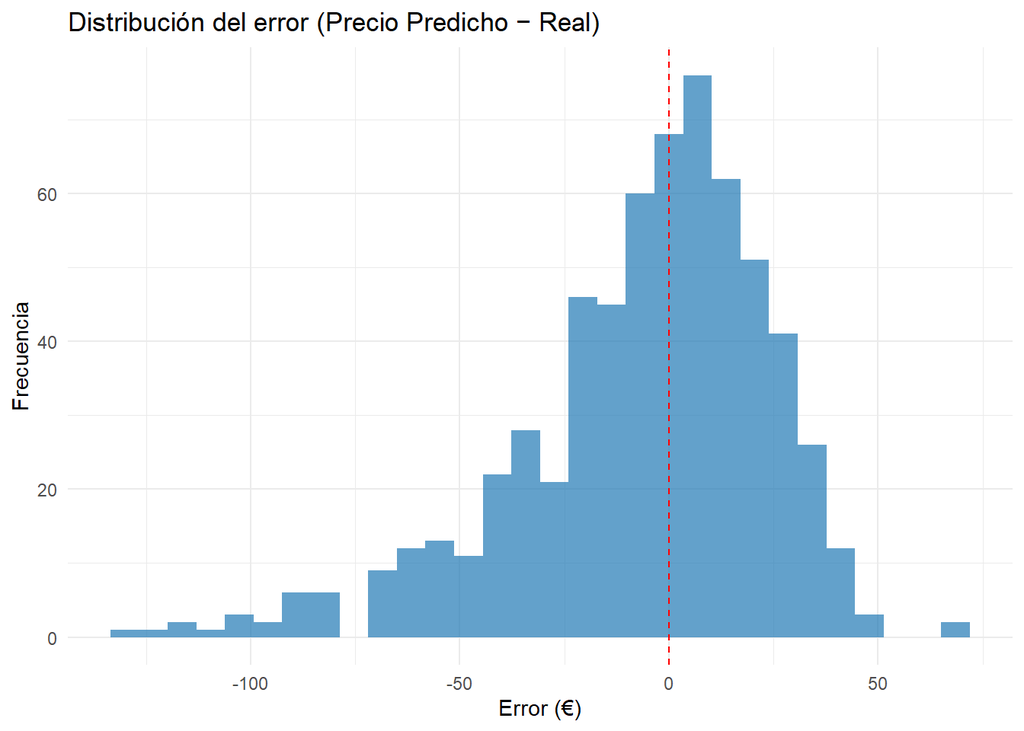

```r
# Calcular error
resultados <- test %>%
  mutate(
    precio_real = exp(log_precio) - 1,
    precio_predicho = pred,
    error = precio_predicho - precio_real
  )

# Histograma
ggplot(resultados, aes(x = error)) +
  geom_histogram(fill = "#1f78b4", bins = 30, alpha = 0.7) +
  geom_vline(xintercept = 0, color = "red", linetype = "dashed") +
  labs(title = "Distribución del error (Precio Predicho − Real)",
       x = "Error (€)", y = "Frecuencia") +
  theme_minimal()
```

El histograma muestra una distribución asimétrica a la izquierda, con la mayoría de los errores concentrados entre -50€ y +50€.

```r
mean_abs_error <- mean(abs(resultados$error))
cat("Error medio absoluto:", round(mean_abs_error, 2), "€")
```

```
## Error medio absoluto: 22.85 €
```

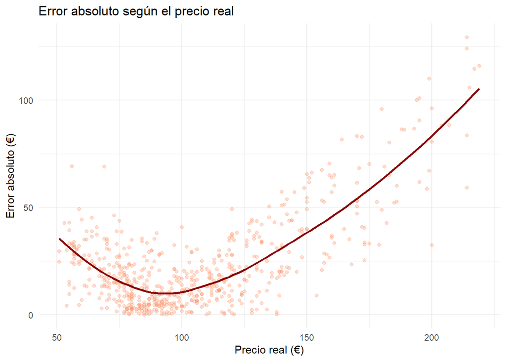

```r
# Scatterplot de error absoluto vs precio real
ggplot(resultados, aes(x = precio_real, y = abs(error))) +
  geom_point(alpha = 0.3, color = "#fc8d62") +
  geom_smooth(method = "loess", se = FALSE, color = "darkred") +
  labs(title = "Error absoluto según el precio real",
       x = "Precio real (€)",
       y = "Error absoluto (€)") +
  theme_minimal()
```

El gráfico de dispersión muestra que el error absoluto tiende a aumentar con el precio real:

El modelo predice bien en el rango medio-bajo de precios, pero su rendimiento disminuye conforme el precio aumenta.

```r
x_vars <- c(
  "bedrooms", "bathrooms", "accommodates", "precio_ponderado_barrio_media",
  "fiabilidad_normalizada", "puntuacion_media_normal_reseñas"
)


predecir_precio_vivienda <- function(bedrooms, bathrooms, accommodates, barrio) {

  # Validación
  if (!(barrio %in% barrios$barrio)) {
    stop("❌ El barrio indicado no existe en los datos.")
  }

  # Obtener valores del barrio
  p_bar <- barrios %>% filter(barrio == !!barrio) %>% pull(precio_ponderado_barrio_media) %>% .[1]
  reseñas <- barrios_reseñas %>% filter(barrio == !!barrio) %>% pull(puntuacion_media_normal_reseñas) %>% .[1]
  fiabilidad <- mean(datos_modelo$fiabilidad_normalizada, na.rm = TRUE)

  # Crear nuevo ejemplo como named vector
  nueva <- data.frame(
    bedrooms = bedrooms,
    bathrooms = bathrooms,
    accommodates = accommodates,
    precio_ponderado_barrio_media = p_bar,
    fiabilidad_normalizada = fiabilidad,
    puntuacion_media_normal_reseñas = reseñas
  )

  # Reordenar columnas según x_vars
  nueva <- nueva[, x_vars]

  # Predecir con XGBoost
  pred_log <- predict(modelo_xgb, newdata = as.matrix(nueva))
  pred_precio <- exp(pred_log) - 1

  cat("📍 Precio estimado para nueva vivienda", ":", round(pred_precio, 2), "€\n")
  return(round(pred_precio, 2))
}

predecir_precio_vivienda(1,2,4,'LA GRAN VIA')
```

```
## 📍 Precio estimado para nueva vivienda : 106.91 €
```

```
## [1] 106.91
```